# A Time Series-Based Trading Strategy: Exploring the Link Between Oil Prices and CAD/USD

Anirudh Samaddar

09-04-2025

## Introduction

The central question driving this analysis is- how might the price of crude oil impact global currencies, in particular, for nations with rich oil reserves? My focus is on Canada and the USA, given the relation that the former is the largest foreign supplier of crude oil to the latter. I attempt to explore the relationship, if there is one, between oil prices and the corresponding CAD/USD exchange rate. On a simplified level, the notion that oil price fluctuations would impact the value of the Canadian dollar relative to the USD appealed to me.

My goal here isn’t just to observe this relationship, it’s to test a trading strategy that seeks to profit from it.

While conceptualising a relevant idea for this assignment, my goal was to pursue a topic that fulfilled two conditions- a hypothesis rooted in economic intuition, and sufficient data points to support a well-constructed time series analysis. The process was marked by trying and scrapping multiple ideas (including interest rate differentials and the Big Mac index mispricing), but they fell short of the aforementioned criteria in one or more ways.

## Hypothesis

My primary hypothesis for this project is that significant oil price movements correspond to subsequent directional changes in the CAD/USD exchange rate, albeit with a short lag. As one of the largest oil exporters globally and to the US in particular, the Canadian economy (and consequently, its currency) is considerably linked to global oil prices.

Upon exploring this relationship and its validity and persistence, I believe it can be leveraged to construct a viable trading strategy for the short-term, where the signals are generated following lagged oil returns. The key assumption here is that commodity shocks are priced into currency markets with a delay, which leaves a short window of opportunity for informed trading.

A disclaimer- this project adopts a simplified approach to studying exchange rate fluctuations with reference to oil prices; but it is important to note that a broad range of economic, political, and monetary factors affect exchange rates globally in real time.

## The Data

### Loading and Preparing Data

```r
library(quantmod)
library(dplyr)
library(lubridate)
library(ggplot2)
library(zoo)
library(scales)
library(forecast)
library(tseries)

getSymbols(c("DCOILWTICO", "DEXCAUS"), src = "FRED")
```

```
## [1] "DCOILWTICO" "DEXCAUS"
```

```r
oil <- na.omit(DCOILWTICO)
cad <- na.omit(DEXCAUS)

# Convert xts objects to regular data frames with date column
oil_df <- data.frame(date = index(oil), oil = as.numeric(oil$DCOILWTICO))
cad_df <- data.frame(date = index(cad), cad = as.numeric(cad$DEXCAUS))

# Merge both data sets on common dates
combined_df <- inner_join(oil_df, cad_df, by = "date")

# Calculating daily returns and lagged oil returns
combined_df <- combined_df %>%
  arrange(date) %>%
  mutate(
    oil_ret = (oil / lag(oil)) - 1,
    cad_ret = (cad / lag(cad)) - 1,
    oil_ret_lag2 = lag(oil_ret, 2)
  )
```

### Visualize Prices

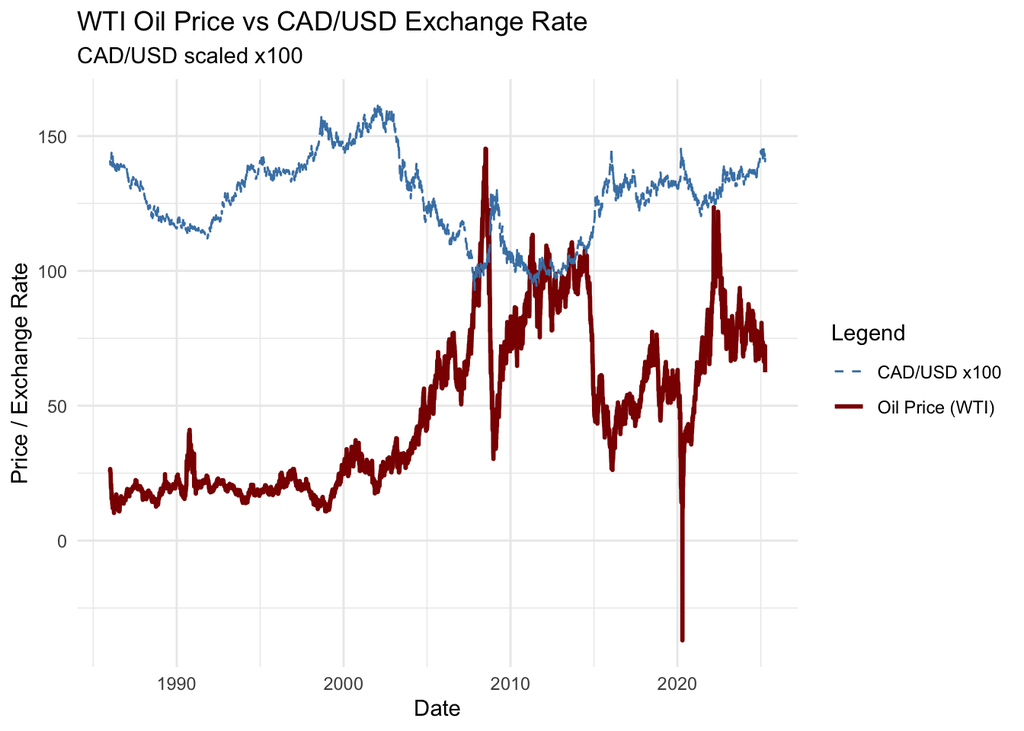

```r
ggplot(combined_df, aes(x = date)) +
  geom_line(aes(y = oil, color = "Oil Price (WTI)"), size = 1) +
  geom_line(aes(y = cad * 100, color = "CAD/USD x100"), linetype = "dashed") +
  scale_color_manual(values = c("Oil Price (WTI)" = "darkred", "CAD/USD x100" = "steelblue")) +
  labs(
    title = "WTI Oil Price vs CAD/USD Exchange Rate",
    subtitle = "CAD/USD scaled x100",
    y = "Price / Exchange Rate",
    x = "Date",
    color = "Legend"
  ) +
  theme_minimal()
```

Few key observations based on the plot: - DEXCAUS represents the USD/CAD exchange rate, meaning it shows how many Canadian Dollars (CAD) are required to purchase 1 US Dollar (USD).

- Since Canada is a major oil exporter, rising global oil prices tend to strengthen the Canadian economy and, in turn, the CAD. This is because higher oil prices boost Canada’s trade balance and attract foreign capital inflows.
- As a result, when oil prices rise, the CAD typically appreciates relative to the USD, which means the USD/CAD rate (DEXCAUS) falls.
- The steep crash in oil prices around 2008–2009 and again in 2020 (due to the Global Financial Crisis and COVID-19 pandemic respectively) are clearly visible, both followed by CAD weakening (CAD/USD rising).
- Since 2021, oil has recovered while CAD/USD has remained relatively steady, possibly reflecting broader macroeconomic forces such as U.S. interest rate policy and inflation dynamics overriding oil’s influence.

### Strategy and Summary Metrics

```r
# Calculating 30-day rolling correlation between 2-day-lag oil return and CAD/USD return
combined_df$rolling_corr_lag2 <- rollapplyr(
  data = combined_df[, c("oil_ret_lag2", "cad_ret")],
  width = 30,
  FUN = function(x) cor(x[, 1], x[, 2], use = "complete.obs"),
  by.column = FALSE,
  fill = NA
)

# Strategy based on minimum oil returns threshold and rolling correlation filter
create_strategy <- function(df, lag = 2, threshold = 0.025, min_corr = 0) {
  signal_col <- paste0("oil_ret_lag", lag)
  df %>%
    mutate(
      signal = case_when(
        .data[[signal_col]] > threshold & rolling_corr_lag2 < min_corr ~ 1, #long CAD
        .data[[signal_col]] < -threshold & rolling_corr_lag2 > min_corr ~ -1, # short CAD
        TRUE ~ 0
      ),
      strategy_return = case_when(
        signal == 1 ~ cad_ret,
        signal == -1 ~ -cad_ret,
        TRUE ~ 0
      )
    )
}

# Apply strategy to dataset
strategy_lag2 <- create_strategy(combined_df)

# Function to evaluate strategy performance metrics
evaluate_strategy <- function(strategy_df, label) {
  strategy_df %>%
    filter(signal != 0) %>%
    summarise(
      Strategy = label,
      Num_Trades = n(),
      Avg_Return = mean(strategy_return, na.rm = TRUE),
      Win_Rate = mean(strategy_return > 0, na.rm = TRUE),
      Median_Return = median(strategy_return, na.rm = TRUE),
      StdDev_Return = sd(strategy_return, na.rm = TRUE)
    )
}

# See results
evaluate_strategy(strategy_lag2, "Lag 2 (Corr < 0)")
```

```
##           Strategy Num_Trades   Avg_Return  Win_Rate Median_Return
## 1 Lag 2 (Corr < 0)       1068 0.0002923325 0.5065543  7.585621e-05
##   StdDev_Return
## 1   0.005656044
```

*Strategy Logic Summary* - The strategy is based on the relationship between WTI oil price changes and the CAD/USD exchange rate. It uses 2-day lagged oil returns to generate signals for trading CAD.

- A 30-day rolling correlation between lagged oil returns and CAD/USD returns is calculated to filter out noise.
- Go long CAD (i.e., expect CAD to strengthen) when:
  - Oil prices increase significantly (return > +2.5%)
  - And the 30-day rolling correlation is negative ( less than 0)
- Go short CAD (i.e., expect CAD to weaken) when:
  - Oil prices drop significantly (return < -2.5%)
  - And the 30-day rolling correlation is positive (more than 0)
- The strategy executes a 1-day trade based on the generated signal.

### Plots

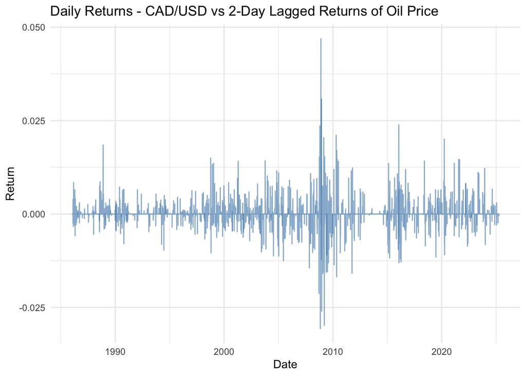

```r
plot_strategy <- function(strategy_df, label) {
  df <- strategy_df %>%
    mutate(
      cum_return = cumsum(strategy_return),
      vol = zoo::rollapply(strategy_return, width = 30, FUN = sd, fill = NA, align = "right")
    )

  p1 <- ggplot(df, aes(x = date, y = strategy_return)) +
    geom_line(color = "steelblue", alpha = 0.6) +
    labs(title = paste("Daily Returns -", label), x = "Date", y = "Return") +
    theme_minimal()

  p2 <- ggplot(df, aes(x = date, y = vol)) +
    geom_line(color = "darkorange") +
    labs(title = paste("30-Day Rolling Volatility -", label), x = "Date", y = "Volatility") +
    theme_minimal()

  p3 <- ggplot(df, aes(x = date, y = cum_return)) +
    geom_line(color = "darkgreen", linewidth = 1) +
    labs(title = paste("Cumulative Return -", label), x = "Date", y = "Cumulative Return") +
    theme_minimal()

  list(p1, p2, p3)
}

plots_lag2 <- plot_strategy(strategy_lag2, "CAD/USD vs 2-Day Lagged Returns of Oil Price")
print(plots_lag2[[1]])
```

The early 2000s saw frequent trading signals but in both directions, making the strategy returns appear more volatile. The strategy shows large spikes in return between 2008 and 2010, which aligns with the global financial crisis and extreme movements in both oil prices and currency markets. Interestingly, few trades are observed between 2013 and 2015, likely due to weaker oil price momentum or a breakdown in the oil-CAD relationship during that time.

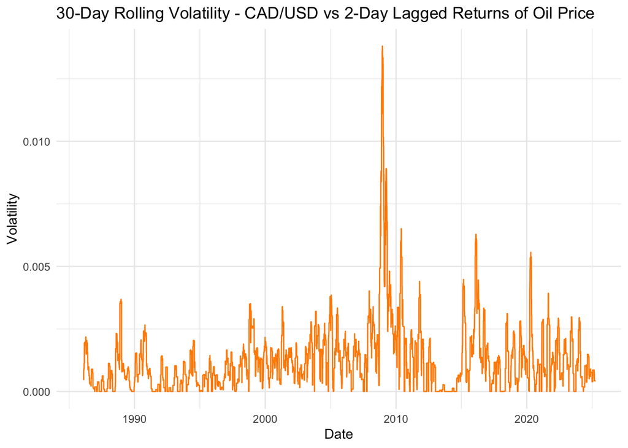

```r
print(plots_lag2[[2]])
```

The volatility of strategy returns remains relatively calm up until 2008. The spikes align with the global financial crisis and sharp swings in both oil prices and FX markets. Post-2010 till 2015, the strategy becomes notably less volatile, indicating more stable market behavior or fewer extreme trading signals. Interestingly, occasional short-lived spikes reappear during oil price crashes like in 2015 and during the COVID-19 shock in 2020. Overall, the plot shows that the strategy reacts sharply to macroeconomic disruptions but settles during calm periods.

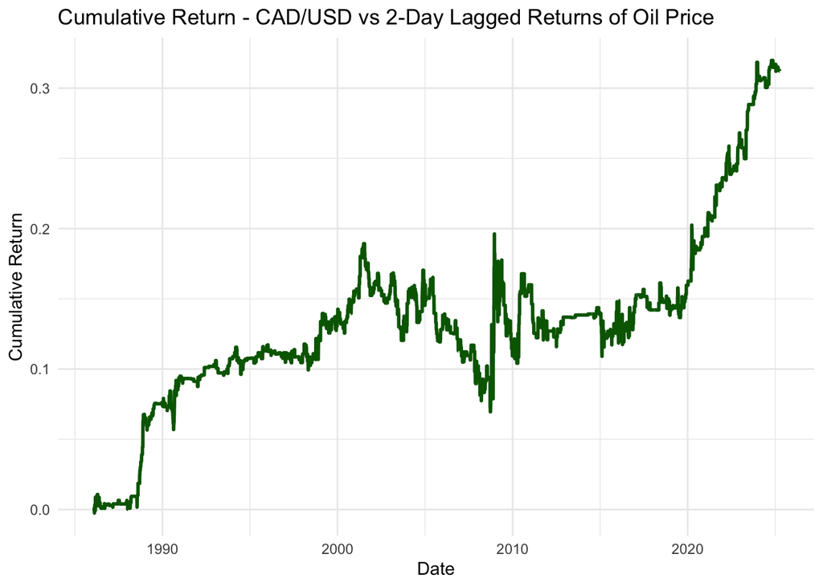

```r
print(plots_lag2[[3]])
```

The cumulative returns plot highlights the long-term profitability of the strategy, especially post-2019 where performance has been consistently upward. Notable drawdowns occurred during the 2008–2010 crisis and the flat period that followed until 2016, possibly due to lower oil volatility or weaker correlation. However, the recent strong gains reflect more aligned movements between oil and CAD/USD, validating the updated correlation-based strategy logic. Overall, the strategy appears to recover well and compound positively in the long run.

## Time Series Analysis

```r
# White Noise Test
Box.test(strategy_lag2$strategy_return, lag = 20, type = "Ljung-Box")
```

```
##
##  Box-Ljung test
##
## data:  strategy_lag2$strategy_return
## X-squared = 142.23, df = 20, p-value < 2.2e-16
```

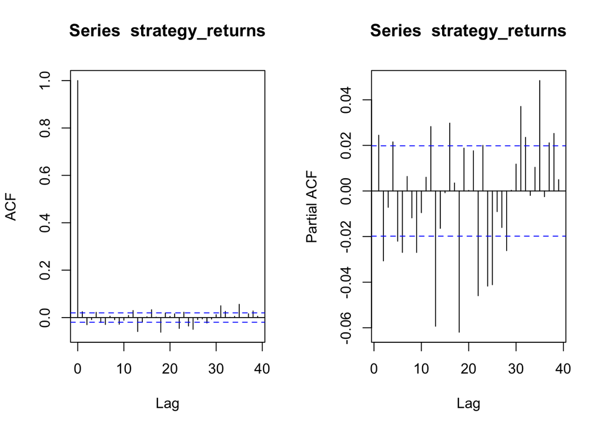

```r
# ACF and PACF
strategy_returns <- na.omit(strategy_lag2$strategy_return)
par(mfrow = c(1, 2))
acf(strategy_returns)
pacf(strategy_returns)
```

```r
par(mfrow = c(1, 1))
```

The Ljung-Box test returns a statistically significant result (p-value < 0.05), suggesting that the strategy returns are *not white noise* and there is some degree of autocorrelation present.

From the ACF plot, we observe that autocorrelations at most lags fall within the 95% confidence bands, indicating that the series is largely uncorrelated over time. This is expected in return series as the FX rates are assumed to replicate a random walk.

Together, these findings suggest that while the series behaves somewhat randomly in the short run, there may still be exploitable patterns as the relation between FX rates and oil prices are dictated by several other complex factors.

## STL Decomposition

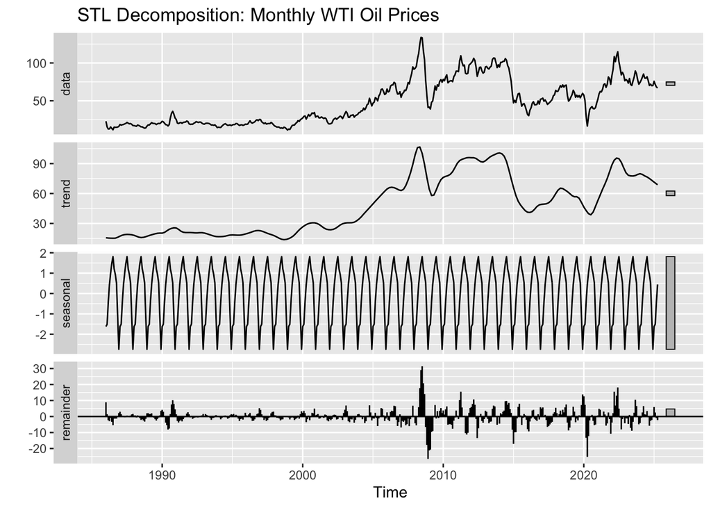

```r
monthly_oil <- oil_df %>%
  mutate(month = floor_date(date, "month")) %>%
  group_by(month) %>%
  summarise(oil_price = mean(oil, na.rm = TRUE), .groups = 'drop')

oil_ts <- ts(monthly_oil$oil_price,
             start = c(year(min(monthly_oil$month)), month(min(monthly_oil$month))),
             frequency = 12)

oil_stl <- stl(oil_ts, s.window = "periodic")
autoplot(oil_stl) +
  labs(title = "STL Decomposition: Monthly WTI Oil Prices")
```

I performed STL decomposition on oil prices to better understand the structure of oil price movements, since my trading strategy is directly based on lagged oil returns.

This analysis helps break down the oil price time series, which allows me to examine whether oil prices move in systematic and potentially predictable ways.

By identifying long-term trends, for example, if the oil prices are set to rise, I can capitalise on this information by leveraging my trades that go long on the CAD.

The strong seasonal component shows regular spikes, it is important to note the magnitude of the variations that are very small compared to the data and the trend.

# ARIMA Model

```r
auto_model <- auto.arima(strategy_returns, seasonal = FALSE)
summary(auto_model)
```

```
## Series: strategy_returns
## ARIMA(2,0,2) with non-zero mean
##
## Coefficients:
##           ar1      ar2     ma1     ma2  mean
##       -0.1776  -0.9666  0.1912  0.9502     0
## s.e.   0.0114   0.0086  0.0142  0.0102     0
##
## sigma^2 = 3.475e-06:  log likelihood = 47577.62
## AIC=-95143.23   AICc=-95143.22   BIC=-95100.11
##
## Training set error measures:
##                         ME        RMSE          MAE MPE MAPE      MASE
## Training set -3.384386e-07 0.001863636 0.0004952459 NaN  Inf 0.6327489
##                    ACF1
## Training set 0.01199353
```

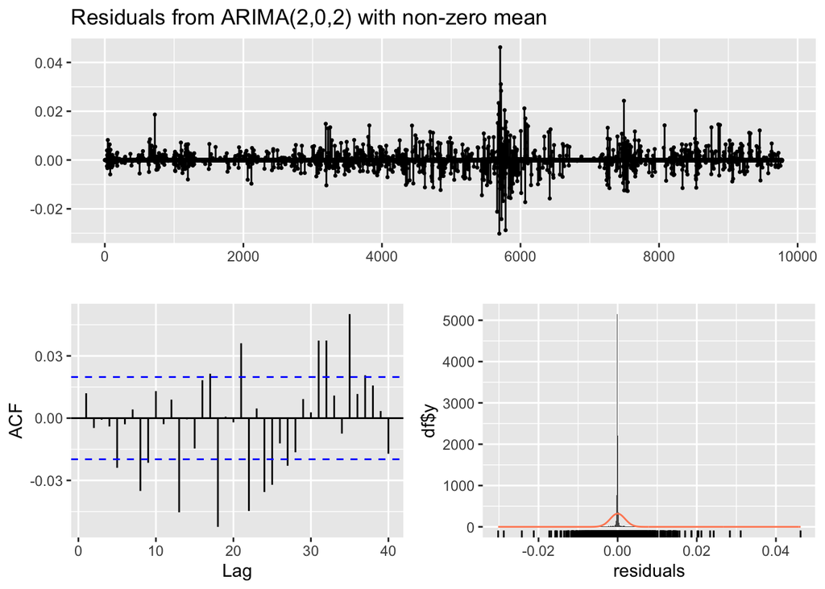

```
##
##  Ljung-Box test
##
## data:  Residuals from ARIMA(2,0,2) with non-zero mean
## Q* = 25.876, df = 6, p-value = 0.0002348
##
## Model df: 4.   Total lags used: 10
```

```r
checkresiduals(auto_model)
```

To further examine whether any predictable patterns exist in my trading strategy returns, I applied an ARIMA model. The auto.arima() function selected an ARIMA(2,0,2) model with a non-zero mean, indicating that the strategy exhibits short-term dependencies based on its own past returns and past forecast errors. The integration order of 0 confirms that the strategy return series is already stationary and does not require differencing.

## Conclusion

Over the course of working on this project, I attempted to explore the relationship between global crude oil prices and the CAD/USD exchange rate. The idea for this subject was grounded in Canada being an oil export stalwart, specifically to the US. Based on this observation, I attempted to use a signal-based trading strategy, which was constructed on lagged oil returns and rolling correlations. Utilising the time series analysis techniques this course exposed me to and data visualisation, it uncovered how oil price fluctuations can influence the Canadian dollar value relative to the US dollar.

As demonstrated, the simplified trading strategy I employed managed to generate a steady stream of trades, coupled with modest cumulative returns. Subsequently, the analysis presented of volatility, returns, and the ACF/PACF plots indicate that there is limited autocorrelation. With STL decomposition, I was able to analyse the oil price trends, and ARIMA modelling helped me gauge if certain transient dependencies were worth exploiting.

Overall, the strategy analyses an instance of combining economic intuition with quantitative filters. Future improvements could include testing more dynamic thresholds, exploring multi-factor models, or validating the strategy in different economic regimes. In conlusion, I found this project to be engaging and one that taught me how time series tools can be applied to real-world macro-financial relationships in a structured way.